# Illustration of the numerical approximations

Hugo Gruson

Christine Andraud

Willy Daney de Marcillac

Serge Berthier

Marianne Elias

Doris Gomez

# Preamble

This notebook contains the necessary code and instructions to reproduce our results published in the paper: “Quantitative characterisation of iridescent colours in biological studies: a novel method using optical theory”. This notebook format allows you to conviently browse the final result in your usual web browser. Should you wish to run the code yourself, you code download a rmarkdown (`.Rmd`) file from the notebook.

This code was running fine when this file was last compiled (2018-09-03). It is however possible that in the meantime, some of the packages we use have been updated and it does not work anymore. In this case, please contact us. You can also check the full list and version of the package we used in the `session_info()` at the end of this notebook.

```r
suppressPackageStartupMessages(library(tidyverse))
theme_set(theme_minimal())
knitr::opts_chunk$set(warning = FALSE)
```

# Fresnel factor is constant for small angles

Let us define functions that compute the value of the Fresnel factor for given values of optical indices $n_1$ and $n_2$ and incident angle $\theta$:

```r
fresnel_s <- function(n1, n2, theta) {
  theta = theta * pi / 180

  num <- n1*cos(theta) - n2*sqrt(1-(n1*sin(theta)/n2)^2)
  den <- n1*cos(theta) + n2*sqrt(1-(n1*sin(theta)/n2)^2)

  Rs = (num/den)^2

  return(Rs)
}
fresnel_p <- function(n1, n2, theta) {
  theta = theta * pi / 180

  num <- n1*sqrt(1-(n1*sin(theta)/n2)^2) - n2*cos(theta)
  den <- n1*sqrt(1-(n1*sin(theta)/n2)^2) + n2*cos(theta)

  Rp <- (num/den)^2

  return(Rp)
}
fresnel <- function(n1, n2, theta) {

  Rs <- fresnel_p(n1, n2, theta)
  Rp <- fresnel_s(n1, n2, theta)

  R <- 0.5 * (Rp + Rs)

  return(R)
}
```

We are focusing on what happens at small angles (assumption 1):

```r
res <- tibble("Angle" = seq(from = 0, to = 90, length.out = 100),
              "Rs" = fresnel_s(n_air, n_mel, Angle),
              "Rp" = fresnel_p(n_air, n_mel, Angle),
              "Reff" = 0.5 * (Rs+Rp))
res <- gather(res, Rtype, "Fresnel factor R", -Angle)
```

where:

- $R_s$ is the amount of reflected light in $s$ polarisation
- $R_p$ is the amount of reflected light in $p$ polarisation
- $R_{eff}$ is the total amount of reflected light, no matter the polarisation

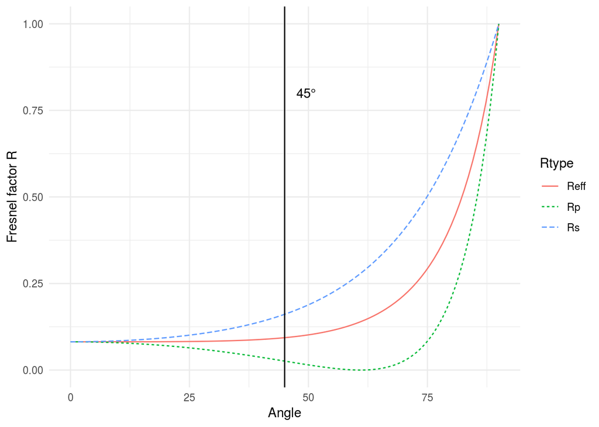

```r
ggplot(res, aes(x = Angle, y = `Fresnel factor R`,
                col = Rtype, linetype = Rtype)) +
  geom_line() +
  geom_vline(xintercept = 45) +
  annotate(geom = "text", x = 1.1 * 45, y = 0.8, label = "45°")
```

# Reflectivity in the transfer matrix model for small angles

Simulations can only estimate what happens when the angular span varies. Because the signal reflected out of the specular position is due to the disorder in the alignment of the multilayer, it cannot be properly tested through simulation. It would lead to a circular reasoning where the output is defined in the input.

We ran simulations using a transfer matrix model (Yeh 2005) implemented in the python package `EMpy` (Lbolla 2018; https://lbolla.github.io/EMpy/).

## Hue

First, we simulated a 10 layers multilayer where each layer was composed of 100nm melanin-100nm air-100nm melanin, separated by 100nm keratin (KK-type in Dürrer 1975, that can be found in hummingbirds and starlings for example).

```r
res_transfermatrix = read.csv("res_transfermatrix.csv")
```

[figure not shown]

```r
ggplot(res_transfermatrix, aes(x = Thetas, y = H1_empty)) +
  geom_line() +
  geom_smooth(method = "nls",
              formula = y ~ Hmax * cos(gammaH*x*pi/180),
              method.args = list(start = c(Hmax=570, gammaH=0.6)),
              se = FALSE) +
  xlab("Hue") +
  ylab("Incidence angle (theta_i=theta_r)")
```

The simulation result is in black and the fit by a cosine function is in blue.

Even without an ideal multilayer ($n_1e_1\neq n_2e_1$ in this simulation), the approximation of the hue depending on the angle by a cosine function is quite good.

```r
nls_huecos = nls(H1_empty ~ a * cos(b*Thetas*pi/180),
                 res_transfermatrix,
                 start = c(a = 560, b = 0.6))
pred_huecos = predict(nls_huecos, res_transfermatrix$Thetas)
```

```r
compute_relerror <- function(obs, th) {
  diff = abs(obs-th)
  reldiff = diff/th
  relerror = max(reldiff) * 100

  return(relerror)
}
```

At worst, the error made by this approximation is 0.20%.

## Brightness

Here, we test different types of multilayer structures:

- (100nm keratin / 100nm melanin / 100nm air / 100nm melanin) * 10
- (70nm keratin / 80nm melanin / 60nm air / 80nm melanin) * 10
- (80nm keratin / 80nm melanin / 80nm air / 80nm melanin) * 5
- (80nm keratin / 80 nm melanin) * 10
- (80nm air / 80nm chitin) * 10

```r
transfermatrix_brightness = read.csv("merged_brightness.csv")
transfermatrix_brightness = gather(transfermatrix_brightness, Parameters, Brightness, -Thetas)
```

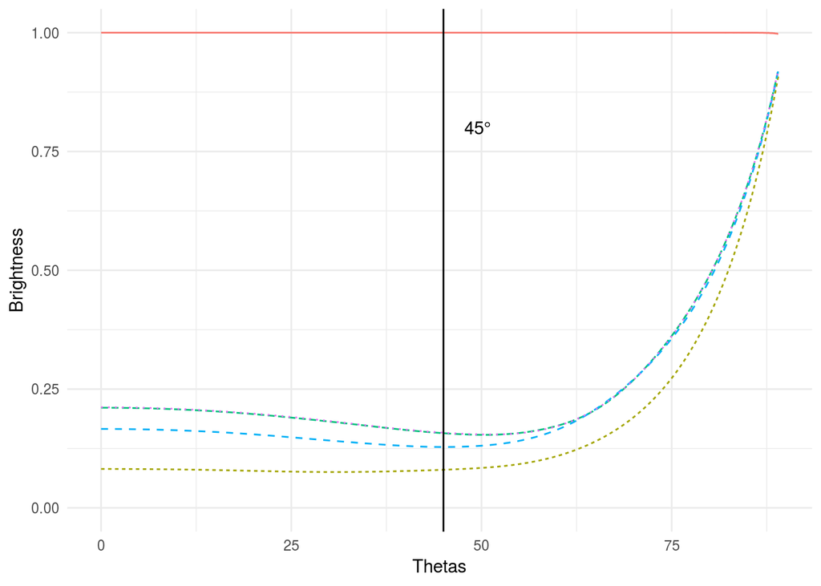

```r
ggplot(transfermatrix_brightness, aes(x = Thetas, y = Brightness,
                                      col = Parameters, linetype = Parameters)) +
  geom_line() +
  ylim(c(0, 1)) +
  theme(legend.position = "none") +
  geom_vline(xintercept = 45) +
  annotate(geom = "text", x = 1.1 * 45, y = 0.8, label = "45°")
```

```r
maxdist2mean = function(vec) {
  max(abs(vec - mean(vec))) * 100
}
maxrelerror = function(vec) {
  max(abs(vec - mean(vec)) / vec) * 100
}
transfermatrix_brightness %>%
  filter(Thetas <= 30) %>%
  group_by(Parameters) %>%
  summarise(`Maximum relative error` = maxrelerror(Brightness),
            `Maximum absolute error` = maxdist2mean(Brightness)) %>%
  knitr::kable()
```

| Parameters | Maximum relative error | Maximum absolute error |
| --- | --- | --- |
| B2_airchitin_10layers_80nm | 0.0000134 | 0.0000134 |
| B2_full_10layers_80nm | 4.9678934 | 0.3746396 |
| B2_hollow_10layers_100nm | 10.5005369 | 1.9078967 |
| B2_hollow_10layers_70.80.60.80nm | 11.1961421 | 1.5877553 |
| B2_hollow_5layers_80nm | 10.4041522 | 1.9015925 |

# Approximation of a sum of cosine functions by a single cosine function for small angles

We test the validity of the approximation $\cos(x)+\cos(\alpha x)=2cos\left(\sqrt{\frac{1+\alpha^2}{2}}x\right)$

Angles are between 0° and 90°. More specifically, we are interested in angles smaller than 45° (small angles assumption)

```r
ang <- seq(from = 0, to = pi/4, length.out = 100)
```

For biological multilayer structures, $\alpha=\frac{n_1}{n_2}$. This ratio is unlikely to be greater than 2. For example, in the case of an air-melanin interface, $\alpha=\frac{1.8}{1}=1.8<2$. We however test for different values of $\alpha$ between 0 and 2 to test its influence.

```r
alpha <- seq(from = 0, to = 2, by = 0.01)
```

Now for the values of the two functions:

```r
exact <-outer(ang, alpha, function(x,y) cos(x) + cos(x * y))

approx <- outer(ang, alpha, function(x,y) 2*cos(sqrt((1+y^2)/2)*x))
```

For nice `ggplot2` plots, we need to convert `exact` and `approx` to `data.frame`s

```r
suppressPackageStartupMessages(library(reshape2))
exact_df <- melt(exact, value.name = "exact", varnames = c("ang", "alpha"))
approx_df <- melt(approx, value.name = "approx", varnames = c("ang", "alpha"))
final_df <- merge(exact_df, approx_df)
final_df$ang <- ang[final_df$ang]*180/pi
```

Everything is now ready for the plot itself:

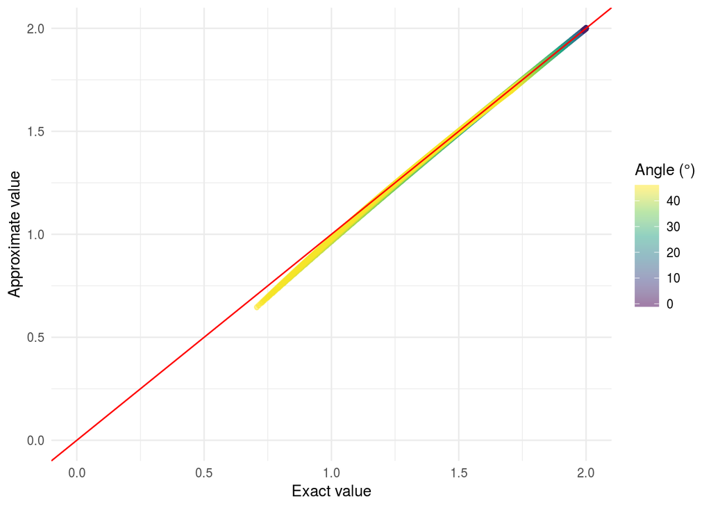

```r
library(ggrastr)
ggplot(final_df, aes(x = exact, y = approx, col = ang)) +
  geom_point_rast() +
  scale_color_viridis_c(alpha = 0.5) +
  geom_abline(slope = 1, intercept = 0, color = "red") +
  theme_minimal() +
  lims(x = c(0, 2), y = c(0, 2)) +
  xlab("Exact value") +
  ylab("Approximate value") +
  labs(color = "Angle (°)")
```

The data points are along the $x=y$ line (first bissectrice). This means that the numerical approximation is very good for angles smaller than $45°$.

# Session info

[session information not shown]

```
 setting  value
 version  R version 3.5.1 (2018-07-02)
 system   x86_64, linux-gnu
 ui       RStudio (1.1.423)
 language en_US
 collate  en_US.UTF-8
 tz       Europe/Paris
 date     2018-09-03
```

```
Packages -----------------------------------------------------------------
```

```
 package     * version date       source
 abind         1.4-5   2016-07-21 CRAN (R 3.5.0)
 assertthat    0.2.0   2017-04-11 CRAN (R 3.5.0)
 backports     1.1.2   2017-12-13 CRAN (R 3.5.0)
 base        * 3.5.1   2018-07-03 local
 base64enc     0.1-3   2015-07-28 CRAN (R 3.5.0)
 bindr         0.1.1   2018-03-13 CRAN (R 3.5.0)
 bindrcpp    * 0.2.2   2018-03-29 CRAN (R 3.5.0)
 bmp           0.3     2017-09-11 cran (@0.3)
 broom         0.5.0   2018-07-17 CRAN (R 3.5.1)
 Cairo         1.5-9   2015-09-26 CRAN (R 3.5.1)
 car           3.0-0   2018-04-02 CRAN (R 3.5.0)
 carData       3.0-1   2018-03-28 CRAN (R 3.5.0)
 cellranger    1.1.0   2016-07-27 CRAN (R 3.5.0)
 cli           1.0.0   2017-11-05 CRAN (R 3.5.0)
 codetools     0.2-15  2016-10-05 CRAN (R 3.5.0)
 colorspace    1.3-2   2016-12-14 CRAN (R 3.5.0)
 compiler      3.5.1   2018-07-03 local
 crayon        1.3.4   2017-09-16 CRAN (R 3.5.0)
 curl          3.2     2018-03-28 CRAN (R 3.5.0)
 data.table    1.11.4  2018-05-27 CRAN (R 3.5.0)
 datasets    * 3.5.1   2018-07-03 local
 devtools      1.13.6  2018-06-27 CRAN (R 3.5.1)
 digest        0.6.15  2018-01-28 CRAN (R 3.5.0)
 dplyr       * 0.7.6   2018-06-29 cran (@0.7.6)
 evaluate      0.11    2018-07-17 cran (@0.11)
 forcats     * 0.3.0   2018-02-19 CRAN (R 3.5.0)
 foreign       0.8-71  2018-07-20 CRAN (R 3.5.1)
 future        1.9.0   2018-07-23 CRAN (R 3.5.1)
 geometry      0.4.0   2018-06-19 Github (davidcsterratt/geometry@d5c98e7)
 ggplot2     * 3.0.0   2018-07-03 CRAN (R 3.5.1)
 ggrastr     * 0.1.5   2018-08-14 Github (VPetukhov/ggrastr@82aa62b)
 git2r         0.23.0  2018-07-17 CRAN (R 3.5.1)
 globals       0.12.1  2018-06-25 CRAN (R 3.5.1)
 glue          1.3.0   2018-07-17 cran (@1.3.0)
 graphics    * 3.5.1   2018-07-03 local
 grDevices   * 3.5.1   2018-07-03 local
 grid          3.5.1   2018-07-03 local
 gridExtra   * 2.3     2017-09-09 CRAN (R 3.5.0)
 gtable        0.2.0   2016-02-26 CRAN (R 3.5.0)
```

[output cut: 57 more lines]

```
 stats       * 3.5.1   2018-07-03 local
 stringi       1.2.4   2018-07-20 cran (@1.2.4)
 stringr     * 1.3.1   2018-05-10 CRAN (R 3.5.0)
 tibble      * 1.4.2   2018-01-22 CRAN (R 3.5.0)
 tidyr       * 0.8.1   2018-05-18 CRAN (R 3.5.0)
 tidyselect    0.2.4   2018-02-26 CRAN (R 3.5.0)
 tidyverse   * 1.2.1   2017-11-14 CRAN (R 3.5.0)
 tiff          0.1-5   2013-09-04 cran (@0.1-5)
 tools         3.5.1   2018-07-03 local
 utils       * 3.5.1   2018-07-03 local
 viridisLite   0.3.0   2018-02-01 CRAN (R 3.5.0)
 withr         2.1.2   2018-03-15 CRAN (R 3.5.0)
 xml2          1.2.0   2018-01-24 CRAN (R 3.5.0)
 yaml          2.2.0   2018-07-25 cran (@2.2.0)
 zip           1.0.0   2017-04-25 CRAN (R 3.5.0)
```